# re_airquality

Vera

2025-03-10

# Report Content

The airquality dataset in R contains air pollution data collected in New York between May and September 1973. The dataset includes six variables:

- Ozone (ppb, parts per billion)
- Solar.R (solar radiation in langleys)
- Wind (wind speed in mph)
- Temp (temperature in degrees Fahrenheit)
- Month (numerical representation of months, 5 = May, etc.)
- Day (day of the month)

# Research Question

How does temperature and wind speed influence ozone concentration in New York’s air during the summer months of 1973?

# Key Statistical Metrics

Mean Ozone Concentration: 42.13 ppb (excluding missing values) Temperature Range: 56°F - 97°F Wind Speed Range: 1.7 - 20.7 mph

# Creating figures to answer my question

```r
library(ggplot2)
library(dplyr)
library(tidyr)
datasets::airquality
```

[output not shown]

[output cut: 139 more lines]

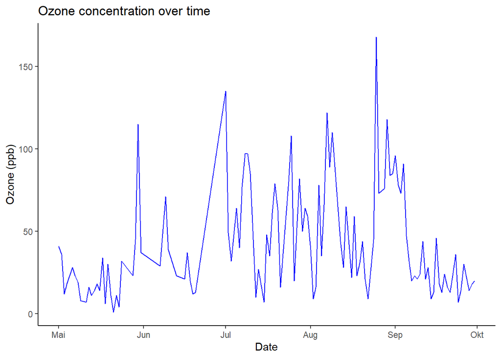

```r
# Create a new "Date" column by combining year, month and day
airquality <- airquality %>%
  drop_na(Ozone) %>% # NA is set to 0
  mutate(Date = as.Date(paste(1973, Month, Day, sep = "-")))

# Plot ozone concentration over time
plotme1 <- ggplot(data = airquality, aes(x = Date, y = Ozone)) +
  geom_line(color = "blue") +  # Line plot, ignoring missing values
  labs(title = "Ozone concentration over time", x = "Date", y = "Ozone (ppb)") +
  theme_classic()
print(plotme1)
```

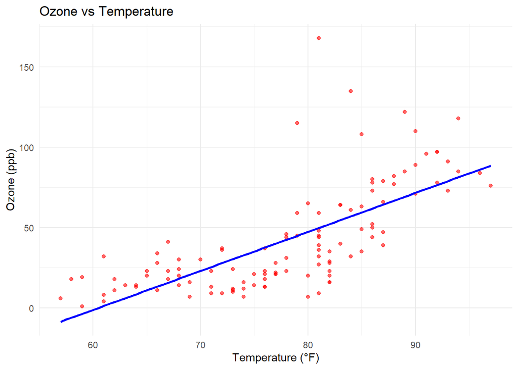

```r
# Scatterplot of Ozone concentration vs Temperature with a fitted regression line
plotme2 <- ggplot(airquality, aes(x=Temp, y=Ozone)) +
  geom_point(color='red', alpha=0.6) +  # Scatter plot with transparent points
  geom_smooth(formula = y~x, method='lm', se=FALSE, color='blue') +  # Linear regression line
  labs(title='Ozone vs Temperature', x='Temperature (°F)', y='Ozone (ppb)') +
  theme_minimal()
print(plotme2)
```

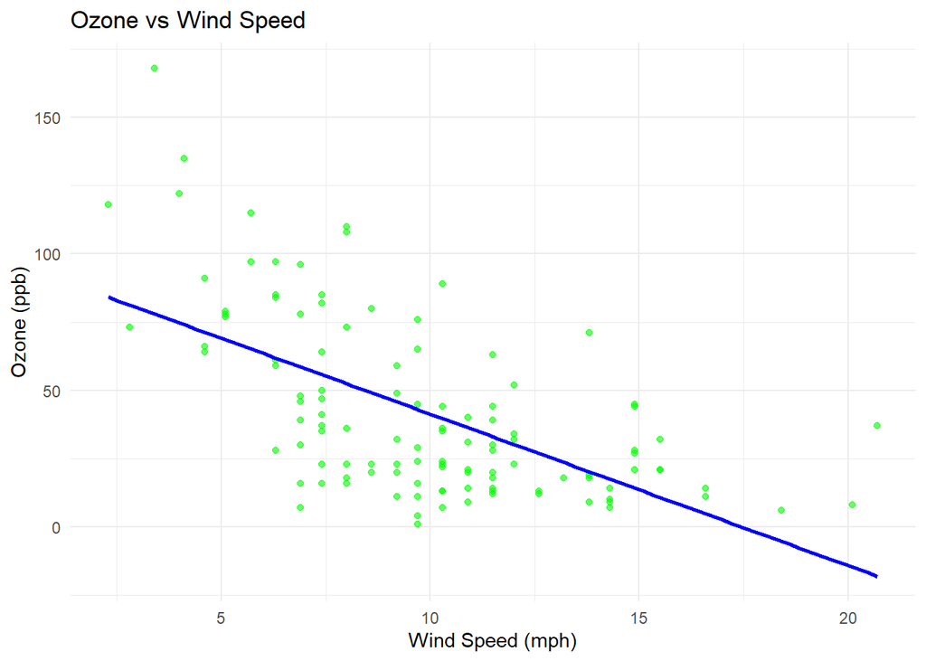

```r
# Scatterplot of Ozone concentration vs Wind Speed with a fitted regression line
plotme3 <- ggplot(airquality, aes(x=Wind, y=Ozone)) +
  geom_point(color='green', alpha=0.6) +  # Scatter plot with transparency
  geom_smooth(formula = y~x, method='lm', se=FALSE, color='blue') +  # Linear regression line
  labs(title='Ozone vs Wind Speed', x='Wind Speed (mph)', y='Ozone (ppb)') +
  theme_minimal()
print(plotme3)
```